# SAE2-06

MOULIN Sarah

# Introduction

Parmi les différentes thématiques j’ai choisi de m’intéresser à celle des entreprises (démographie, secteurs d’activité).  
L’entreprise est la plus petite combinaison d’unités légales qui constitue une unité organisationnelle de production de biens et de services jouissant d’une certaine autonomie de décision, notamment pour l’affectation de ses ressources courantes. Nous avons cherché des fichiers sur l’INSEE à intégrer dans notre base de données. Nous nous sommes interéssé aux données concernant la création des entreprises en France de 2017 à 2021 Une création d’entreprise correspond à la mise en œuvre d’une nouvelle combinaison de facteurs de production avec pour restriction qu’aucune autre entreprise ne soit impliquée dans cet évènement.  
Nous avons ensuite analysé la structure de ces données puis réalisé un schéma relationnel afin d’établir des liens entre nos différentes tables.  
Mon étude portera sur l’évolution des spécificités liées aux entreprises créées de 2017 à 2021.

### Schéma relationnel

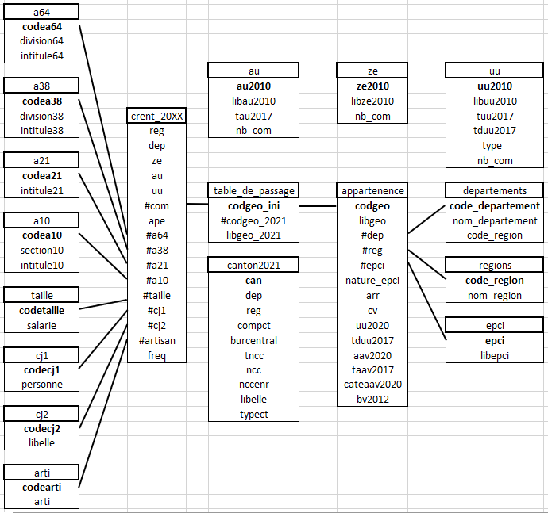

### Initialisation de la connexion

```r
library(DBI)
cpg <- dbConnect(odbc::odbc(), .connection_string = "Driver={PostgreSQL Unicode};",
    timeout = 10)
```

### Création du schéma

```sql
DROP SCHEMA IF EXISTS sae6 CASCADE;
CREATE SCHEMA sae6
```

### Création des tables

```sql
CREATE TABLE sae6.table_de_passage (
  codegeo_ini char(5),
  codgeo_2021 char(5),
  libgeo_2021 varchar(200)
);
CREATE TABLE sae6.ze (
  ze2010 varchar(4),
  libze2010 varchar(200),
  nb_com int
);
CREATE TABLE sae6.uu (
  uu2010 varchar(5),
  libuu2010 varchar(200),
  tuu2017 char(2),
  tduu2017 char(11),
  type_ char(2),
  nb_com int
);
CREATE TABLE sae6.regions (
  code_region varchar(2),
  nom_region varchar(200)
);
CREATE TABLE sae6.epci (
  epci char(9),
  libepci varchar(200)
);
CREATE TABLE sae6.departements (
  code_departement varchar(3),
  nom_departement varchar(200),
  code_region varchar(2)
);
CREATE TABLE sae6.appartenance (
  codgeo char(5),
  libgeo varchar(200),
  dep varchar(3),
  reg varchar(2),
  epci char(9),
  nature_epci char(2),
  arr varchar(5),
  cv varchar(5),
  ze2020 varchar(4),
  uu2020 varchar(5),
  tuu2017 char(2),
  tduu2017 char(2),
  aav2020 char(3),
  taav2017 char(2),
  tdaav2017 char(2),
  cateaav2020 char(2),
  bv2012 char(5)
);
CREATE TABLE sae6.cj2 (
  codecj2 char(2),
  libelle varchar(200)
);
CREATE TABLE sae6.cj1 (
  codecj1 char(2),
  personne varchar(8)
);
CREATE TABLE sae6.canton2021 (
  can char(5),
  dep varchar(3),
  reg varchar(2),
  compct char(2),
  burcentral char(5),
  tncc char(2),
  ncc varchar(200),
  nccenr varchar(200),
  libelle varchar(200),
  typect char(2)
);
CREATE TABLE sae6.au (
  au2010 varchar(3),
  libau2010 varchar(200),
  tau2017 varchar(2),
  nb_com int
);
CREATE TABLE sae6.arti (
  codearti char(2),
  Arti varchar(26)
);
CREATE TABLE sae6.taille (
  codetaille char(2),
  salarie varchar(26)
);
CREATE TABLE sae6.a64 (
  codea64 char(3),
  division64 varchar(6),
  intitule64 varchar(200)
);
CREATE TABLE sae6.a38 (
  codea38 char(2),
  division38 varchar(6),
  intitule38 varchar(200)
);
CREATE TABLE sae6.a21 (
  codea21 char(2),
  intitule21 varchar(200)
);
CREATE TABLE sae6.a10 (
  codea10 char(2),
  section10 varchar(20),
  intitule10 varchar(200)
);
```

### Clés primaires secondaires

```sql
ALTER TABLE sae6.a10 ADD PRIMARY KEY ("codea10") ;
ALTER TABLE sae6.a21 ADD PRIMARY KEY ("codea21") ;
ALTER TABLE sae6.a38 ADD PRIMARY KEY ("codea38") ;
ALTER TABLE sae6.a64 ADD PRIMARY KEY ("codea64") ;
ALTER TABLE sae6.appartenance ADD PRIMARY KEY ("codgeo") ;
ALTER TABLE sae6.arti ADD PRIMARY KEY ("codearti") ;
ALTER TABLE sae6.au ADD PRIMARY KEY ("au2010") ;
ALTER TABLE sae6.canton2021 ADD PRIMARY KEY ("can") ;
ALTER TABLE sae6.cj1 ADD PRIMARY KEY ("codecj1") ;
ALTER TABLE sae6.cj2 ADD PRIMARY KEY ("codecj2") ;
ALTER TABLE sae6.departements ADD PRIMARY KEY ("code_departement") ;
ALTER TABLE sae6.epci ADD PRIMARY KEY ("epci") ;
ALTER TABLE sae6.regions ADD PRIMARY KEY ("code_region") ;
ALTER TABLE sae6.table_de_passage ADD PRIMARY KEY ("codegeo_ini") ;
ALTER TABLE sae6.taille ADD PRIMARY KEY ("codetaille") ;
ALTER TABLE sae6.uu ADD PRIMARY KEY ("uu2010") ;
ALTER TABLE sae6.ze ADD PRIMARY KEY ("ze2010") ;
```

### Clés étrangères secondaires

```sql
ALTER TABLE sae6.appartenance ADD CONSTRAINT fk_epci FOREIGN KEY (epci) REFERENCES sae6.epci (epci);
ALTER TABLE sae6.appartenance ADD CONSTRAINT fk_dep FOREIGN KEY (dep) REFERENCES sae6.departements (code_departement);
ALTER TABLE sae6.appartenance ADD CONSTRAINT fk_reg FOREIGN KEY (reg) REFERENCES sae6.regions (code_region);
--ERROR:  insert or update on table "appartenance" violates foreign key constraint "fk_can"
--DETAIL:  Key (cv)=(69ZZ) is not present in table "canton2021".
--ALTER TABLE sae6.appartenance ADD CONSTRAINT fk_can FOREIGN KEY (cv) REFERENCES sae6.canton2021 (can);
ALTER TABLE sae6.table_de_passage ADD CONSTRAINT fk_codgeo FOREIGN KEY (codgeo_2021) REFERENCES sae6.appartenance (codgeo);
```

### Création des tables principales

```sql
CREATE TABLE sae6.crent_2017 (
  reg varchar(2),
  dep varchar(3),
  ze varchar(4),
  au varchar(3),
  uu char(5),
  com char(5),
  ape char(5),
  a64 char(3),
  a38 char(2),
  a21 char(2),
  a10 char(2),
  taille char(2),
  cj1 char(2),
  cj2 char(2),
  artisan char(2),
  freq varchar(5)
);
CREATE TABLE sae6.crent_2018 (
  reg varchar(2),
  dep varchar(3),
  ze varchar(4),
  au varchar(3),
  uu char(5),
  com char(5),
  ape char(5),
  a64 char(3),
  a38 char(2),
  a21 char(2),
  a10 char(2),
  taille char(2),
  cj1 char(2),
  cj2 char(2),
  artisan char(2),
  freq varchar(5)
);
CREATE TABLE sae6.crent_2019 (
  reg varchar(2),
  dep varchar(3),
  ze varchar(4),
  au varchar(3),
  uu char(5),
  com char(5),
  ape char(5),
  a64 char(3),
  a38 char(2),
  a21 char(2),
  a10 char(2),
  taille char(2),
  cj1 char(2),
  cj2 char(2),
  artisan char(2),
  freq varchar(5)
);
CREATE TABLE sae6.crent_2020 (
  reg varchar(2),
  dep varchar(3),
  ze varchar(4),
  au varchar(3),
  uu char(5),
  com char(5),
  ape char(5),
  a64 char(3),
  a38 char(2),
  a21 char(2),
  a10 char(2),
  taille char(2),
  cj1 char(2),
  cj2 char(2),
  artisan char(2),
  freq varchar(5)
);
CREATE TABLE sae6.crent_2021 (
  reg varchar(2),
  dep varchar(3),
  ze varchar(4),
  au varchar(3),
  uu char(5),
  com char(5),
  ape char(5),
  a64 char(3),
  a38 char(2),
  a21 char(2),
  a10 char(2),
  taille char(2),
  cj1 char(2),
  cj2 char(2),
  artisan char(2),
  freq varchar(5)
);
```

### Clés étrangères principales

Les clés étrangères “fk_com” des “crent_20XX” ne fonctionnant pas, nous ne les créons pas.

```sql
--ERREUR : ERROR:  insert or update on table "crent_20XX" violates foreign key constraint "fk_com"
--DETAIL:  Key (com)=(75101) is not present in table "table_de_passage".
--ALTER TABLE sae6.crent_2017 ADD CONSTRAINT fk_com FOREIGN KEY (com) REFERENCES sae6.table_de_passage (codegeo_ini);
--ALTER TABLE sae6.crent_2018 ADD CONSTRAINT fk_com FOREIGN KEY (com) REFERENCES sae6.table_de_passage (codegeo_ini);
--ALTER TABLE sae6.crent_2019 ADD CONSTRAINT fk_com FOREIGN KEY (com)  REFERENCES sae6.table_de_passage (codegeo_ini)--ALTER TABLE sae6.crent_2020 ADD CONSTRAINT fk_com FOREIGN KEY (com) REFERENCES sae6.table_de_passage (codegeo_ini);
--ALTER TABLE sae6.crent_2021 ADD CONSTRAINT fk_com FOREIGN KEY (com) REFERENCES sae6.table_de_passage (codegeo_ini);
ALTER TABLE sae6.crent_2017 ADD CONSTRAINT fk_a64 FOREIGN KEY (a64) REFERENCES sae6.a64 (codea64);
ALTER TABLE sae6.crent_2018 ADD CONSTRAINT fk_a64 FOREIGN KEY (a64) REFERENCES sae6.a64 (codea64);
ALTER TABLE sae6.crent_2019 ADD CONSTRAINT fk_a64 FOREIGN KEY (a64) REFERENCES sae6.a64 (codea64);
ALTER TABLE sae6.crent_2020 ADD CONSTRAINT fk_a64 FOREIGN KEY (a64) REFERENCES sae6.a64 (codea64);
ALTER TABLE sae6.crent_2021 ADD CONSTRAINT fk_a64 FOREIGN KEY (a64) REFERENCES sae6.a64 (codea64);
ALTER TABLE sae6.crent_2017 ADD CONSTRAINT fk_a38 FOREIGN KEY (a38) REFERENCES sae6.a38 (codea38);
ALTER TABLE sae6.crent_2018 ADD CONSTRAINT fk_a38 FOREIGN KEY (a38) REFERENCES sae6.a38 (codea38);
ALTER TABLE sae6.crent_2019 ADD CONSTRAINT fk_a38 FOREIGN KEY (a38) REFERENCES sae6.a38 (codea38);
ALTER TABLE sae6.crent_2020 ADD CONSTRAINT fk_a38 FOREIGN KEY (a38) REFERENCES sae6.a38 (codea38);
ALTER TABLE sae6.crent_2021 ADD CONSTRAINT fk_a38 FOREIGN KEY (a38) REFERENCES sae6.a38 (codea38);
ALTER TABLE sae6.crent_2017 ADD CONSTRAINT fk_a21 FOREIGN KEY (a21) REFERENCES sae6.a21 (codea21);
ALTER TABLE sae6.crent_2018 ADD CONSTRAINT fk_a21 FOREIGN KEY (a21) REFERENCES sae6.a21 (codea21);
ALTER TABLE sae6.crent_2019 ADD CONSTRAINT fk_a21 FOREIGN KEY (a21) REFERENCES sae6.a21 (codea21);
ALTER TABLE sae6.crent_2020 ADD CONSTRAINT fk_a21 FOREIGN KEY (a21) REFERENCES sae6.a21 (codea21);
ALTER TABLE sae6.crent_2021 ADD CONSTRAINT fk_a21 FOREIGN KEY (a21) REFERENCES sae6.a21 (codea21);
ALTER TABLE sae6.crent_2017 ADD CONSTRAINT fk_a10 FOREIGN KEY (a10) REFERENCES sae6.a10 (codea10);
ALTER TABLE sae6.crent_2018 ADD CONSTRAINT fk_a10 FOREIGN KEY (a10) REFERENCES sae6.a10 (codea10);
ALTER TABLE sae6.crent_2019 ADD CONSTRAINT fk_a10 FOREIGN KEY (a10) REFERENCES sae6.a10 (codea10);
ALTER TABLE sae6.crent_2020 ADD CONSTRAINT fk_a10 FOREIGN KEY (a10) REFERENCES sae6.a10 (codea10);
ALTER TABLE sae6.crent_2021 ADD CONSTRAINT fk_a10 FOREIGN KEY (a10) REFERENCES sae6.a10 (codea10);
ALTER TABLE sae6.crent_2017 ADD CONSTRAINT fk_taille FOREIGN KEY (taille) REFERENCES sae6.taille (codetaille);
ALTER TABLE sae6.crent_2018 ADD CONSTRAINT fk_taille FOREIGN KEY (taille) REFERENCES sae6.taille (codetaille);
ALTER TABLE sae6.crent_2019 ADD CONSTRAINT fk_taille FOREIGN KEY (taille) REFERENCES sae6.taille (codetaille);
ALTER TABLE sae6.crent_2020 ADD CONSTRAINT fk_taille FOREIGN KEY (taille) REFERENCES sae6.taille (codetaille);
ALTER TABLE sae6.crent_2021 ADD CONSTRAINT fk_taille FOREIGN KEY (taille) REFERENCES sae6.taille (codetaille);
ALTER TABLE sae6.crent_2017 ADD CONSTRAINT fk_cj1 FOREIGN KEY (cj1) REFERENCES sae6.cj1 (codecj1);
ALTER TABLE sae6.crent_2018 ADD CONSTRAINT fk_cj1 FOREIGN KEY (cj1) REFERENCES sae6.cj1 (codecj1);
ALTER TABLE sae6.crent_2019 ADD CONSTRAINT fk_cj1 FOREIGN KEY (cj1) REFERENCES sae6.cj1 (codecj1);
ALTER TABLE sae6.crent_2020 ADD CONSTRAINT fk_cj1 FOREIGN KEY (cj1) REFERENCES sae6.cj1 (codecj1);
ALTER TABLE sae6.crent_2021 ADD CONSTRAINT fk_cj1 FOREIGN KEY (cj1) REFERENCES sae6.cj1 (codecj1);
ALTER TABLE sae6.crent_2017 ADD CONSTRAINT fk_cj2 FOREIGN KEY (cj2) REFERENCES sae6.cj2 (codecj2);
ALTER TABLE sae6.crent_2018 ADD CONSTRAINT fk_cj2 FOREIGN KEY (cj2) REFERENCES sae6.cj2 (codecj2);
ALTER TABLE sae6.crent_2019 ADD CONSTRAINT fk_cj2 FOREIGN KEY (cj2) REFERENCES sae6.cj2 (codecj2);
ALTER TABLE sae6.crent_2020 ADD CONSTRAINT fk_cj2 FOREIGN KEY (cj2) REFERENCES sae6.cj2 (codecj2);
ALTER TABLE sae6.crent_2021 ADD CONSTRAINT fk_cj2 FOREIGN KEY (cj2) REFERENCES sae6.cj2 (codecj2);
ALTER TABLE sae6.crent_2017 ADD CONSTRAINT fk_arti FOREIGN KEY (artisan) REFERENCES sae6.arti (codearti);
ALTER TABLE sae6.crent_2018 ADD CONSTRAINT fk_arti FOREIGN KEY (artisan) REFERENCES sae6.arti (codearti);
ALTER TABLE sae6.crent_2019 ADD CONSTRAINT fk_arti FOREIGN KEY (artisan) REFERENCES sae6.arti (codearti);
ALTER TABLE sae6.crent_2020 ADD CONSTRAINT fk_arti FOREIGN KEY (artisan) REFERENCES sae6.arti (codearti);
ALTER TABLE sae6.crent_2021 ADD CONSTRAINT fk_arti FOREIGN KEY (artisan) REFERENCES sae6.arti (codearti);
```

### Importation des données

```bash
echo "\copy sae6.a10 FROM '/srv/alumni/iut2203848/sae_analyse_reporting_dataviz/donnee/A10.csv' WITH DELIMITER AS ';' CSV HEADER" | psql
```

```
## COPY 12
```

```bash
echo "\copy sae6.a21 FROM '/srv/alumni/iut2203848/sae_analyse_reporting_dataviz/donnee/A21.csv' WITH DELIMITER AS ';' CSV HEADER" | psql
```

```
## COPY 21
```

```bash
echo "\copy sae6.a38 FROM '/srv/alumni/iut2203848/sae_analyse_reporting_dataviz/donnee/A38.csv' WITH DELIMITER AS ';' CSV HEADER" | psql
```

```
## COPY 39
```

```bash
echo "\copy sae6.a64 FROM '/srv/alumni/iut2203848/sae_analyse_reporting_dataviz/donnee/A64.csv' WITH DELIMITER AS ';' CSV HEADER" | psql
```

```
## COPY 65
```

```bash
echo "\copy sae6.arti FROM '/srv/alumni/iut2203848/sae_analyse_reporting_dataviz/donnee/Arti.csv' WITH DELIMITER AS ';' CSV HEADER" | psql
```

```
## COPY 2
```

```bash
echo "\copy sae6.taille FROM '/srv/alumni/iut2203848/sae_analyse_reporting_dataviz/donnee/Taille.csv' WITH DELIMITER AS ';' CSV HEADER" | psql
```

```
## COPY 15
```

```bash
echo "\copy sae6.au FROM '/srv/alumni/iut2203848/sae_analyse_reporting_dataviz/donnee/AU.csv' WITH DELIMITER AS ';' CSV HEADER" | psql
```

```
## COPY 793
```

```bash
echo "\copy sae6.canton2021 FROM '/srv/alumni/iut2203848/sae_analyse_reporting_dataviz/donnee/canton2021.csv' WITH DELIMITER AS ',' CSV HEADER" | psql
```

```
## COPY 2290
```

```bash
echo "\copy sae6.cj1 FROM '/srv/alumni/iut2203848/sae_analyse_reporting_dataviz/donnee/cj1.csv' WITH DELIMITER AS ';' CSV HEADER" | psql
```

```
## COPY 2
```

```bash
echo "\copy sae6.cj2 FROM '/srv/alumni/iut2203848/sae_analyse_reporting_dataviz/donnee/cj2.csv' WITH DELIMITER AS ';' CSV HEADER" | psql
```

```
## COPY 38
```

```bash
echo "\copy sae6.epci FROM '/srv/alumni/iut2203848/sae_analyse_reporting_dataviz/donnee/EPCI.csv' WITH DELIMITER AS ';' CSV HEADER" | psql
```

```
## COPY 1255
```

```bash
echo "\copy sae6.regions FROM '/srv/alumni/iut2203848/sae_analyse_reporting_dataviz/donnee/regions.csv' WITH DELIMITER AS ',' CSV HEADER" | psql
```

```
## COPY 18
```

```bash
echo "\copy sae6.departements FROM '/srv/alumni/iut2203848/sae_analyse_reporting_dataviz/donnee/departements.csv' WITH DELIMITER AS ',' CSV HEADER" | psql
```

```
## COPY 101
```

```bash
echo "\copy sae6.appartenance FROM '/srv/alumni/iut2203848/sae_analyse_reporting_dataviz/donnee/table-appartenance-geo-communes-21.csv' WITH DELIMITER AS ';' CSV HEADER" | psql
```

```
## COPY 34965
```

```bash
echo "\copy sae6.table_de_passage FROM '/srv/alumni/iut2203848/sae_analyse_reporting_dataviz/donnee/table_passage_geo2003_geo2021.csv' WITH DELIMITER AS ';' CSV HEADER" | psql
```

```
## COPY 36720
```

```bash
echo "\copy sae6.uu FROM '/srv/alumni/iut2203848/sae_analyse_reporting_dataviz/donnee/UU.csv' WITH DELIMITER AS ';' CSV HEADER" | psql
```

```
## COPY 2289
```

```bash
echo "\copy sae6.ze FROM '/srv/alumni/iut2203848/sae_analyse_reporting_dataviz/donnee/ZE.csv' WITH DELIMITER AS ';' CSV HEADER" | psql
```

```
## COPY 322
```

```bash
echo "\copy sae6.crent_2017 FROM '/srv/alumni/iut2203848/sae_analyse_reporting_dataviz/donnee/crent_2017.csv' WITH DELIMITER AS ';' CSV HEADER" | psql
```

```
## COPY 334468
```

```bash
echo "\copy sae6.crent_2018 FROM '/srv/alumni/iut2203848/sae_analyse_reporting_dataviz/donnee/crent_2018.csv' WITH DELIMITER AS ';' CSV HEADER" | psql
```

```
## COPY 364033
```

```bash
echo "\copy sae6.crent_2019 FROM '/srv/alumni/iut2203848/sae_analyse_reporting_dataviz/donnee/crent_2019.csv' WITH DELIMITER AS ';' CSV HEADER" | psql
```

```
## COPY 464167
```

```bash
echo "\copy sae6.crent_2020 FROM '/srv/alumni/iut2203848/sae_analyse_reporting_dataviz/donnee/crent_2020.csv' WITH DELIMITER AS ';' CSV HEADER" | psql
```

```
## COPY 416653
```

```bash
echo "\copy sae6.crent_2021 FROM '/srv/alumni/iut2203848/sae_analyse_reporting_dataviz/donnee/crent_2021.csv' WITH DELIMITER AS ';' CSV HEADER" | psql
```

```
## COPY 480034
```

# Analyses

### L’évolution de la création d’entreprises de 2017 à 2021

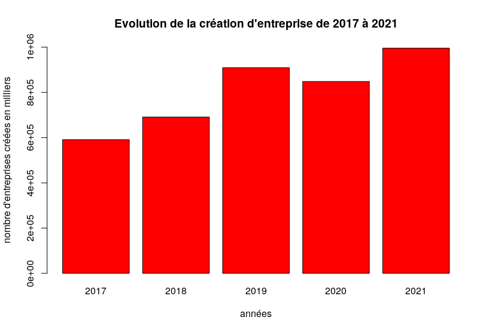

```r
r1=sum(crent_2017$FREQ)
r2=sum(crent_2018$FREQ)
r3=sum(crent_2019$FREQ)
r4=sum(crent_2020$FREQ)
r5=sum(crent_2021$FREQ)



barplot(c(r1,r2,r3,r4,r5),ylim=c(0,1000000),col="red",main="Evolution de la création d'entreprise de 2017 à 2021",col.axis="black",col.main="black", names.arg=barnames,xlab="années",ylab="nombre d'entreprises créées en milliers")

barnames<-c("2017","2018","2019","2020","2021")
```

### Part de personnes morales et physiques des entreprises créées en France en 2017 et en 2021

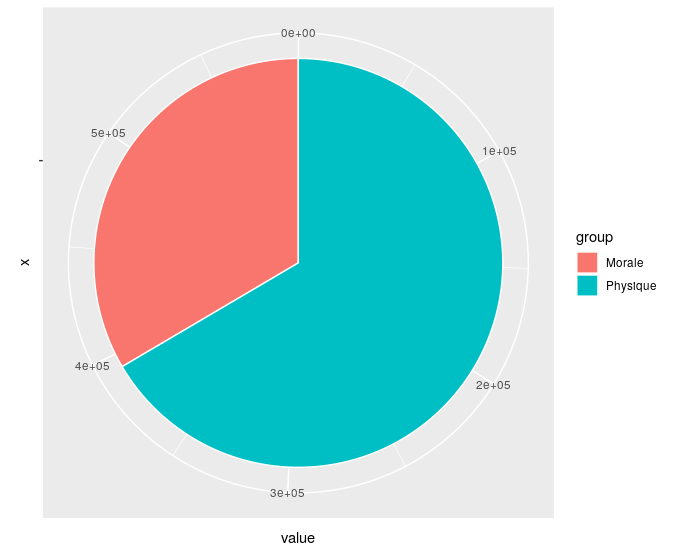

```r
j8=tapply(crent_2017$FREQ,crent_2017$CJ1,sum)


df <- data.frame(
  group = c("Morale", "Physique"),
  value = j8
)



ggplot(df, aes(x="", y=value, fill=group)) +
  geom_bar(stat="identity", width=1, color="white") +
  coord_polar("y", start=0)
```

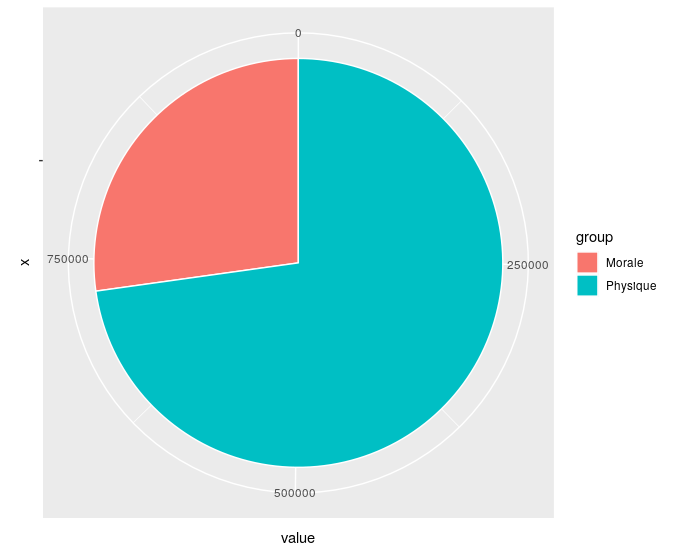

```r
j7=tapply(crent_2021$FREQ,crent_2021$CJ1,sum)


df <- data.frame(
  group = c("Morale", "Physique"),
  value = j7
)



ggplot(df, aes(x="", y=value, fill=group)) +
  geom_bar(stat="identity", width=1, color="white") +
  coord_polar("y", start=0)
```

Le diagramme en camembert ci-dessus représente la part de personnes morales et physiques des entreprises créées en France en 2017 et en 2021.  
Une personne morale constitue une société tandis qu’une personne physique représente une entreprise indivuduelle (micro-entrepreneur) . On remarque alors que la part des micro-entrepreneurs à augmenté depuis 2017 est qu’elle représente en 2021 près de 75% des entreprises créées. La part des créations d’entreprise par des auto-entrepreneurs devient alors de plus en plus importante. En 2021, la hausse a été encore plus forte malgré le Covid. Certaines personnes ont profité de la crise pour entreprendre, se diriger vers de l’entreprenariat. On pense alors aux nouveaux livreurs uber eats et deliveroo qui se lance dans ce domaine lors de l’explosion de la demande sur ses plateformes durant le confinement.

### Part d’entreprises artisanales et non-artisanales parmi les entreprises créées en France en 2017 et en 2021

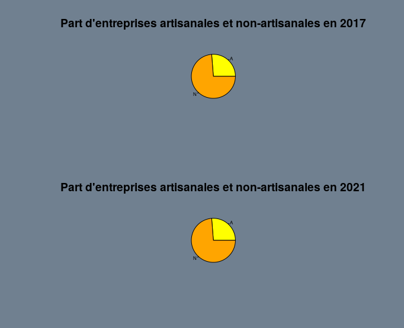

```r
par(mfrow=c(2,1))

par(bg="slategray",fg="black")

j=tapply(crent_2017$FREQ,crent_2017$ARTISAN,sum)

pie(j,col=c("yellow","orange"),labels=names(j),main="Part d'entreprises artisanales et non-artisanales en 2017",cex=0.5)

j2=tapply(crent_2021$FREQ,crent_2021$ARTISAN,sum)

pie(j2,col=c("yellow","orange"),labels=names(j2),main="Part d'entreprises artisanales et non-artisanales en 2021",cex=0.5)
```

On constate alors que même si le nombre de création d’entreprises à considèrablement augmenter depuis 2017, la proportion d’entreprises artisanales et non-artisanales reste la même de 2017 à 2021.

### Répartition des entreprises créées en 2017 par secteur d’activité

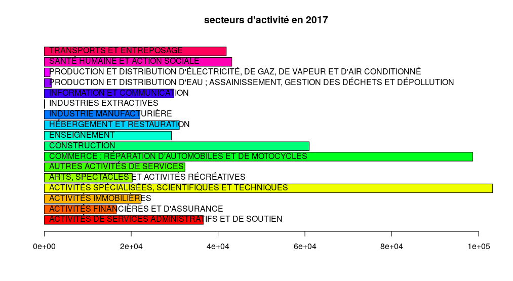

```r
sect_acti_2017 = ' SELECT sae6.regions."code_region", sae6.regions."nom_region", sae6.a21."intitule21", sae6.crent_2017."freq"
FROM sae6.crent_2017, sae6.regions, sae6.a21
WHERE sae6.crent_2017.REG = sae6.regions.code_region
AND sae6.crent_2017.a21 = sae6.a21.codea21



;'

par(mfrow=c(1,1))

w=dbGetQuery(cpg,sect_acti_2017)

j3=tapply(crent_2017$FREQ,w$intitule21,sum)


#BARPLOT
g=barplot(c(j3), horiz=T, main="secteurs d'activité en 2017", axisnames = F, col=rainbow(17))
text(0,g, rownames(j3), pos=4, xpd= NA)
```

Le diagramme en barre ci-dessus représente les 17 secteurs d’activité des entreprises créées en 2017.  
Le secteur d’activité le plus commun des entreprises créées en 2017 est celui des activités spécialisées, scientifiques et techniques. Le deuxième est le secteur du commerce; de la réparation d’automobiles et de motocycles. Le troisième est le secteur de la construction. On remarque alors que les secteurs tertiaires et secondaires sont les plus représentés.

### Répartition des entreprises créées en 2021 par secteur d’activité

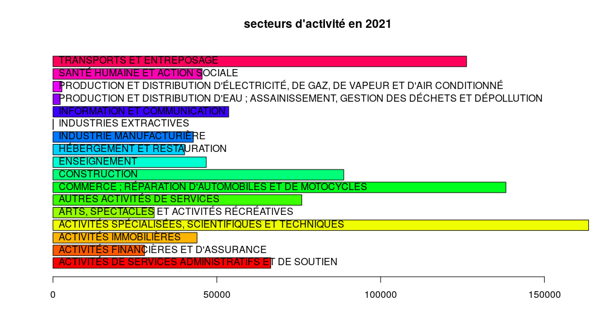

```r
sect_acti_2021 = ' SELECT sae6.regions."code_region", sae6.regions."nom_region", sae6.a21."intitule21", sae6.crent_2021."freq"
FROM sae6.crent_2021, sae6.regions, sae6.a21
WHERE sae6.crent_2021.REG = sae6.regions.code_region
AND sae6.crent_2021.a21 = sae6.a21.codea21



;'

u=dbGetQuery(cpg,sect_acti_2021)


j6=tapply(crent_2021$FREQ,u$intitule21,sum)
j6
sum(j6)
g=barplot(j6, horiz=T, main="secteurs d'activité en 2021", axisnames = F, col=rainbow(17))
text(0,g, rownames(j6), pos=4, xpd= NA)
```

Le diagramme en barre ci-dessus représente les 17 secteurs d’activité des entreprises créées en 2021. Comme en 2017 le secteur d’activité le plus commun des entreprises créées en 2021 est celui des activités spécialisées, scientifiques et techniques. Le deuxième est le secteur du commerce; de la réparation d’automobiles et de motocycles. Le troisième est le secteur du transport et entreprosage qui a explosé depuis 2017. Le secteur de la construction, troisième en 2017, reste quand même l’un des principaux secteurs de création d’entreprise en 2021, il descend à la quatrième place.

### Nombre d’entreprises créées en 2017 par région

[figure not shown]

```r
sect_acti_2 = ' SELECT sae6.regions."code_region", sae6.regions."nom_region", sae6.a21."intitule21", sae6.crent_2017."freq"
FROM sae6.crent_2017, sae6.regions, sae6.a21
WHERE sae6.crent_2017.REG = sae6.regions.code_region
AND sae6.crent_2017.a21 = sae6.a21.codea21



;'

par(mfrow=c(1,1))

f=dbGetQuery(cpg,sect_acti_2)

j10=tapply(crent_2017$FREQ,f$nom_region,sum)

g=barplot(c(j10), horiz=T, main="nb entreprises créées en 2021 par région", axisnames = F, col=rainbow(17))
text(0,g, rownames(j10), pos=4, xpd= NA)
```

### Nombre d’entreprises créées en 2021 par région

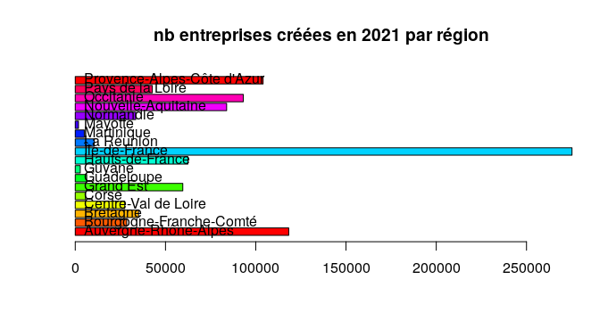

```r
sect_acti_20 = ' SELECT sae6.regions."code_region", sae6.regions."nom_region", sae6.a21."intitule21", sae6.crent_2021."freq"
FROM sae6.crent_2021, sae6.regions, sae6.a21
WHERE sae6.crent_2021.REG = sae6.regions.code_region
AND sae6.crent_2021.a21 = sae6.a21.codea21



;'

par(mfrow=c(1,1))

f=dbGetQuery(cpg,sect_acti_20)

j9=tapply(crent_2021$FREQ,f$nom_region,sum)

g=barplot(c(j9), horiz=T, main="nb entreprises créées en 2021 par région", axisnames = F, col=rainbow(17))
text(0,g, rownames(j9), pos=4, xpd= NA)
```

Les régions ayant le plus d’entreprises créées en 2017 et 2021 sont donc les régions Ile-de-France (275206 en 2021), la région Auvergne-Rhône-Alpes (118277 en 2021) et la région PACA (104068 en 2021). Un tel résultat n’est pas étonnant car celles-ci sont les régions les plus dynamiques de France.